# Button

# Buttons let users make choices

The `Button` is an essential and flexible node for all user interfaces. You can use buttons to start actions, make choices, and provide information about currently enabled modes and options.

In this guide, you will learn how to:

- Set up a `Button` and use its key methods and signals.
- Animate your buttons for better user feedback.
- Dynamically create buttons for turn-based combat and shop items.
- Create toggleable buttons and trigger them with hotkeys.
- Add buttons to a group so the user can select only one at once.

Contents:

- Button’s key features
  - Button text formatting
  - Press options
  - Signals
- How to use a Button in practice
  - Making Buttons with animations
  - Creating buttons for turn-based combat
  - Creating buttons for shop items
  - Enabling a build mode with a toggle
  - Activating an airstrike with a shortcut
  - Selecting a weapon from a group
- Troubleshooting
  - The pressed signal doesn’t emit when pressing a button from code
- Your questions
  - How can I make it so pressing down at the bottom of a menu wraps to the top?
  - Can I stop buttons from being focused at all?
  - When should I use a TextureButton?
  - Can I make my Button only respond to right clicks?

## Button’s key features

### Button text formatting

In the same way as a `Label`, a `Button` comes with a text display determined by the *Text* property. The *Align* property lets you align your text to the left, center, or right sections of your `Button`.

The `Button` text won’t clip if it becomes wider than the `Button` itself. Instead, the `Button` will increase in size to accommodate the new text. You can enable the *Clip Text* property to cut the text off.

There can only be one line of text in a `Button`’s *Text* property. If you want more lines, you should consider putting a `Label` on top of the `Button`. Make sure to set the `Label`’s *Mouse -> Filter* to *Ignore* so the user’s mouse input will still reach the `Button`.

### Press options

The `Button` node has properties that change how players can press the button.

By default, pressing a button releases itself immediately. However, with the *Toggle* property enabled, the button will stay pressed when clicked. You will need to click it again to return to its original state. Toggling is very useful for controlling states and giving a visual indication that something has changed until the user clicks the `Button` again.

The *Disabled* property will prevent the `Button` from being affected by the user.

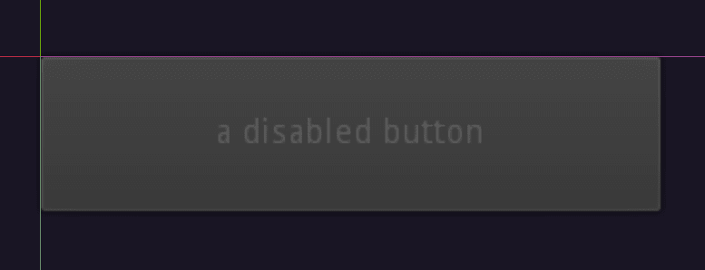

### Signals

A `Button` has four signals that tell us how the user interacted with the `Button`:

1. `pressed`
2. `toggled`
3. `button_down`
4. `button_up`

The `pressed` signal emits when the user presses the `Button`. By default, this emits when the user releases their click after clicking on the `Button` in question. You can make a button emit this signal as soon as the player clicks the button by setting *Action Mode -> Button Press*.

The `Button` has to have *Toggle Mode* enabled to use the `toggled` signal. This signal is useful for its `button_pressed` parameter, which reports the state of the button when you pressed it. This is the better signal for toggleable buttons compared to `pressed` since `pressed` only reports when someone clicks the button, not the state of the button.

The two signals `button_up` and `button_down` can help you catch other edge cases. They are ideal when you’re waiting until a button is pressed or released.

For example, if you want to play an animation while a button is pressed, you can `yield()` until the `button_up` signal is emitted, and stop the animation like so:

```
func button_down() -> void:
    $AnimationPlayer.play("cursor_loop")
    yield(self, "button_up")
    $AnimationPlayer.stop()
```

## How to use a Button in practice

Now we’ll see some practical uses of a `Button`.

### Making Buttons with animations

You can bring a lot of extra life to your games by adding appealing animations to your interfaces. Buttons can be animated to grow, rotate, and move when clicked or passed over.

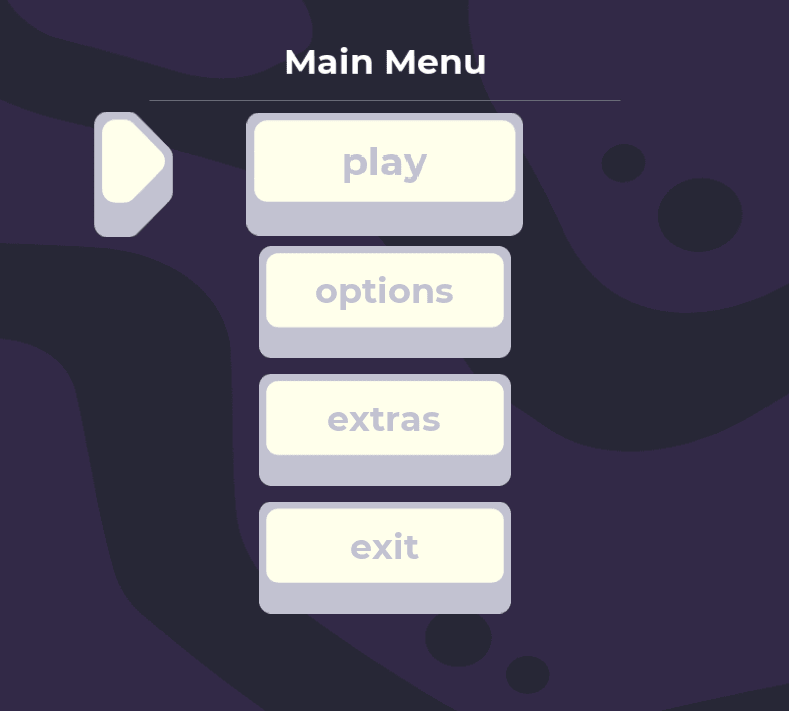

We can use a `Tween` and a `Sprite` node to create an appealing main menu. The menu will have a selection indicator pointing at the active `Button` for controller accessibility.

```
# The button is bound as a parameter to the button_pressed function in an array
# with the square brackets
button.connect("pressed", self, "button_pressed", [button])
```

When making this connection, it’s important to bind the `Button` as a parameter, so we know which `Button` was pressed.

**Note:** When you add a bind to a signal, the values are passed to the function as a new parameter. This binding lets us distinguish all of our button presses from one another by accessing the signal’s source `Button`. We show this new binding by adding an argument on the end of an existing function.

```
func _ready() -> void:
    var buttons := menu_button_group.get_buttons()
    for button in buttons:
        # Allows mouse and keyboard to share selector when selecting buttons
        button.connect("mouse_entered", button, "grab_focus")
        button.connect("focus_entered", self, "move_to_button", [button])
        button.connect("focus_exited", self, "unfocus_button", [button])
        button.connect("pressed", self, "animate_button_press", [button])
```

Whenever a button becomes focused, we want to move the pointer to that `Button` and increase the `Button`’s scale using a `Tween`.

```
func move_to_button(button: Button) -> void:
    tween.stop(self, "position")
    tween.interpolate_property(
        self,
        "position",
        position,
        button.rect_global_position,
        0.15,
        Tween.TRANS_QUAD,
        Tween.EASE_IN_OUT
    )
    tween.interpolate_property(
        button,
        "rect_scale",
        button.rect_scale,
        Vector2.ONE * 1.1,
        0.3,
        Tween.TRANS_CUBIC,
        Tween.EASE_IN_OUT
    )
    tween.start()
```

All of the menu buttons are in a `Container`, which overwrites their position. As a result, we cannot animate the position of the buttons at all. However, we can still animate its rotation, scale, and other properties.

On `pressed` events, we can do a bunch of small animations:

- Hitting the `Button` with the selector’s offset.
- Collapsing the `Button` by decreasing its scale.
- Shaking the `Button` with its rotation.

```
func animate_button_press(button: Button) -> void:
    tween.stop(self, "offset")
    tween.interpolate_property(
        self, "offset", Vector2(0, 57), Vector2(-128, 57), 0.5, Tween.TRANS_ELASTIC, Tween.EASE_OUT
    )
    tween.interpolate_property(
        button, "rect_scale", button.rect_scale, Vector2.ZERO, 0.5, Tween.TRANS_ELASTIC
    )
    tween.interpolate_property(
        button, "rect_rotation", 30, 0, 0.5, Tween.TRANS_ELASTIC, Tween.EASE_OUT
    )
    emit_signal("pressed_animation_finished")
    # We use a delay to reset the scale after the above animations finished
    tween.interpolate_property(
        button,
        "rect_scale",
        Vector2.ZERO,
        Vector2.ONE,
        0.3,
        Tween.TRANS_BOUNCE,
        Tween.EASE_OUT,
        0.75
    )
    tween.start()
```

### Creating buttons for turn-based combat

Many games create and update buttons dynamically. For example, a turn-based game like *Pokemon* uses buttons when the player chooses attacks. Only four options will appear if you’ve learned four attacks. Here, the name of each attack is updated to match what your Pokemon knows.

[figure not shown]

While we could create a unique scene with every combination of attacks, a much more flexible way would be to create and update buttons as they’re needed, and connect their signals at runtime.

For our combat buttons, we have an `AnimationPlayer` with four attack animations. We can create a button for each animation and trigger them by pressing the `Button`.

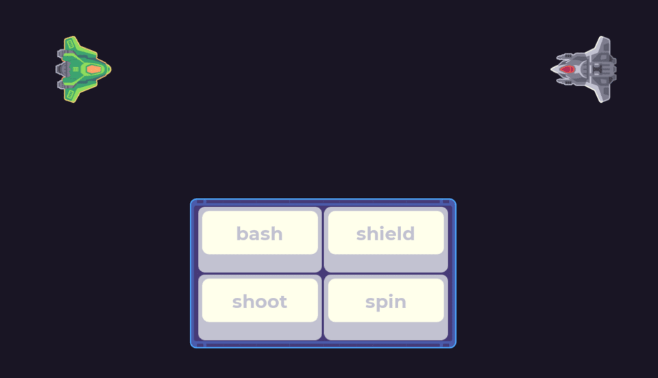

You can create a new node using code by referring to the name of the class, and calling the `new()` function.

```
var button = Button.new()
```

Now that the `Button` exists, we can set this new `Button`’s properties, like *Text* and *Size Flags*. When we’re ready to add this `Button` to our scene, we can use the `add_child()` function to add it as a child of a `Container`.

**Note:** If you want to change several properties at a time when creating a `Button` in code, it can be more convenient to create and instance a `Button` scene that has the properties you want, instead of a new default `Button`.

The final step to setting up the `Button` is connecting its pressed signal.

You can connect the signal straight to the `AnimationPlayer`’s play function and pass in the animation’s name to play with a binding. Alternatively, you could connect the signal to a function and decide which animation to play depending on the source `Button`.

```
export var player_animator_path: NodePath

onready var _player_animator: AnimationPlayer = get_node(player_animator_path)
onready var _container := $NinePatchRect/GridContainer


func _ready() -> void:
    for attack in _player_animator.get_animation_list():
        var button := Button.new()
        button.text = attack
        button.size_flags_horizontal = SIZE_EXPAND_FILL
        button.size_flags_vertical = SIZE_EXPAND_FILL
        _container.add_child(button)
        button.connect("pressed", _player_animator, "play", [attack])
```

### Creating buttons for shop items

Another case where buttons shine is a shop with varying stock. You can dynamically create buttons with associated information, like what items they contain and how much they cost.

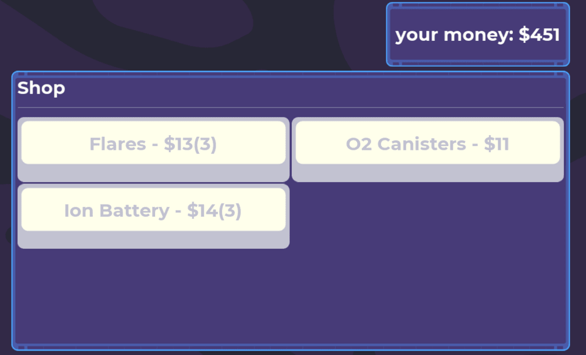

We can create a script to hold an array of item names, their cost, and the quantity of items in-stock.

```
var items := {
    "Rocket Fuel": {"cost": 15, "amount": 4},
    "O2 Canisters": {"cost": 11, "amount": 2},
    "Ion Battery": {"cost": 14, "amount": 6},
    "Rocket": {"cost": 25, "amount": 4},
    "MKIII Cannon": {"cost": 300, "amount": 1},
    "MKII Cannon": {"cost": 200, "amount": 1},
    "MKI Cannon": {"cost": 100, "amount": 1},
    "Repair supplies": {"cost": 8, "amount": 5},
}
```

```
func populate_shop() -> void:
    for item_name in items:
        var shop_item := shop_item_scene.instance()
        var item_data: Dictionary = items[item_name]
        shop_item.setup(item_name, item_data.cost, item_data.amount)
        _item_grid.add_child(shop_item)
        shop_item.connect("pressed", self, "purchase", [shop_item])
```

```
var cost := 0
var quantity := 1


func setup(name_in: String, cost_in: int, quantity_in: int) -> void:
    name = name_in
    cost = cost_in
    quantity = quantity_in
    update_text()


func buy() -> void:
    quantity -= 1
    disabled = quantity < 1
    update_text()
```

Finally, back in the shop window, we can set up the purchase function. If the user has enough money to pay for that item, we can decrease their cash appropriately and call the buy function on the `Button` representing that item.

```
func purchase(item: ShopItem) -> void:
    if player_cash >= item.cost:
        player_cash -= item.cost
        update_money_label()
        item.buy()
```

If you’re interested in creating a drag-and-drop inventory system as a way to supplement a shop system like this, read the PanelContainer guide.

### Enabling a build mode with a toggle

In some real-time strategy games, you can toggle the ability to place units on the map using a button.

You can use the `toggled` signal of a `Button` to display icons and other build mode-specific UI elements.

When you press the button, a build icon becomes visible and clicking in the game world places a new unit.

In this demo, we use the visibility of the build icon as our boolean logic, instead of creating a new variable to enable or disable the build mode.

Alternatively, you can also do this boolean check with the *Pressed* property of the `Button`, to reduce variables in the code.

```
## The maximum number of elements you can place on the map.
const MAX_BUILT_COUNT := 60

export (Array, Texture) var items := []

onready var _environment: Node2D = $Environment
onready var _build_preview: Sprite = $BuildPreview
onready var _build_button: Button = find_node("BuildModeButton")


func _ready() -> void:
    randomize_item_to_build()
    _build_preview.visible = false
    _build_button.connect("toggled", self, "set_preview_visibility")


func _process(delta: float) -> void:
    # Every frame, we place the ghost under the mouse cursor.
    _build_preview.position = get_local_mouse_position()


func _unhandled_input(event: InputEvent) -> void:
    if _build_preview.visible and event.is_action_pressed("click"):
        randomize_item_to_build()
        var item = Sprite.new()
        item.texture = _build_preview.texture
        # When playing full demos, as we have multiple screens placed next to
        # one another, we need to offset the sprite's position.
        item.position = _build_preview.position

        _environment.add_child(item)
        if _environment.get_child_count() > MAX_BUILT_COUNT:
            _environment.remove_child(_environment.get_child(0))


# We assign a random item to this node to display a ghost of the element the
# player will build.
func randomize_item_to_build() -> void:
    items.shuffle()
    _build_preview.texture = items.front()


func set_preview_visibility(visibility: bool) -> void:
    _build_preview.visible = visibility
```

### Activating an airstrike with a shortcut

You can trigger a `Button` using key pressed or specific input events.

[figure not shown]

All buttons have a *Shortcut* property. You can add an `InputEvent` to the `ShortCut`, and triggering that input will press the `Button`. There are also options for setting input strength and whether to set the button’s `pressed` property to be true or false if it is toggleable.

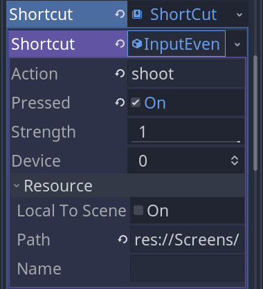

To create the airstrike, set the toggle property to true for the `Button`, so its state is persistent, then connect the `Button`’s toggled signal to your airstrike script.

When the user clicks on the button, we can check the `Button`’s state. If the `Button` is active, we can fire our airstrike.

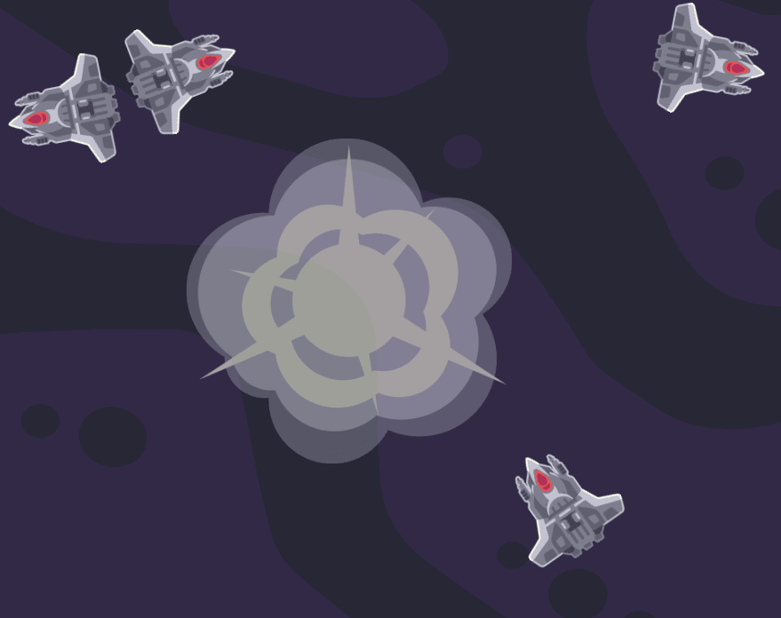

The airstrike we’ve created disables the `Button`, plays an animation, and damages all bodies in the area.

Once the animation has finished, we can re-enable the `Button` and toggle it off.

```
func _unhandled_input(event: InputEvent) -> void:
    if event.is_action_pressed("click") and can_strike():
        launch_air_strike()


func can_strike() -> bool:
    return visible and not _anim_player.is_playing()


func launch_air_strike() -> void:
    # We disable the button to prevent toggling the airstrike mode during an air
    # strike.
    _button.disabled = true

    for body in get_overlapping_bodies():
        if body.has_method("take_damage"):
            body.take_damage()

    _anim_player.play("explosion")
    yield(_anim_player, "animation_finished")
    _button.disabled = false
    _button.pressed = false


func toggle_visibility(visibility: bool) -> void:
    visible = visibility
```

### Selecting a weapon from a group

You can group buttons so that only one toggles at a time. You may recognize this as the behavior of a radio button.

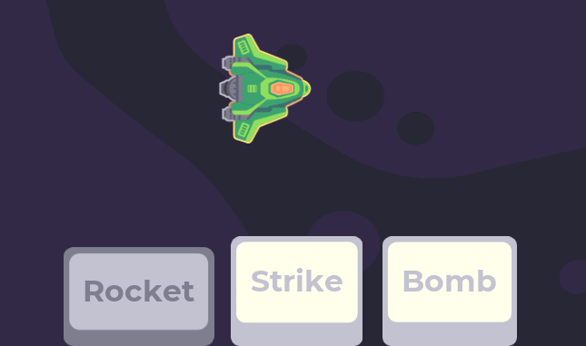

Unlike `CheckButton` or `CheckBox`, using `Button` nodes with a `ButtonGroup` resource gives you more control over the number of toggleable options.

You can use grouped buttons for any mutually-exclusive toggleable buttons:

- Choosing a class for a character.
- Deciding if an order will attack, move, hold a position, or patrol in an RTS.
- Selecting an active ability in a MOBA.

A `ButtonGroup` is the resource that groups buttons together. We will use one to pick between multiple weapons, where only one is active at a time.

You can create a `ButtonGroup` in the group property of your `Button`. Then you can save it as a resource to be added to the other buttons you want to also be in this group.

A `ButtonGroup` has a few useful functions:

1. `get_buttons()`, which returns a list of all the buttons in the group.
2. `get_pressed_button()`, which gets a single pressed button in that group.

We can connect each `Button`’s toggled signal to a shared toggle function with the `Button` itself as an additional binding argument. This way we can tell which button was pressed.

We have a `Dictionary` of the weapon names, which correspond to the `PackedScene` exported variables in the same script. Looking up the names of the weapons in this dictionary returns the `PackedScene`, which we give to the player script’s `weapon` variable.

When a button is activated, we can remove the currently equipped weapon from the player, set the correct weapon from the `Dictionary` as a new weapon, and add it as a child of the player.

```
export var rocket: PackedScene
export var gattling: PackedScene
export var bomb: PackedScene
export var player_path: NodePath

var weapon_list := {}

onready var _player: KinematicBody2D = get_node(player_path)
onready var _buttons := $ButtonContainer.get_children()


func _ready() -> void:
    weapon_list = {"Rocket": rocket, "Gattling": gattling, "Bomb": bomb}
    for button in _buttons:
        button.connect("toggled", self, "button_toggled", [button])
    _buttons[0].pressed = true


func button_toggled(toggle_value: bool, button: Button) -> void:
    if not toggle_value:
        return
    set_weapon(button.text)


func set_weapon(weapon_name: String) -> void:
    var weapon = weapon_list[weapon_name].instance()
    _player.change_weapon(weapon)
```

## Troubleshooting

### The pressed signal doesn’t emit when pressing a button from code

Buttons offer a convenient `pressed` signal to know when the user pressed them.

In code, you can use the `pressed` property to make the button look pressed. However, when you do so, the corresponding signal won’t emit.

Nothing appears in the *Output* panel with the following example until you manually click on the button.

```
extends Button

func _ready() -> void:
    connect("pressed", self, "_on_pressed")
    pressed = true

func _on_pressed() -> void:
    print("Someone pressed me")
```

As a result, to get the signal to emit from code, you have to emit it manually:

```
func _ready() -> void:
    connect("pressed", self, "_on_pressed")
    pressed = true
    emit_signal("pressed") # The message "Someone pressed me" appears in the output
```

However, if you turn on the `Button`’s *Toggle Mode*, the signal works with code. The following example prints “Someone toggled me” to the *Output* panel.

```
extends Button

func _ready() -> void:
    toggle_mode = true
    connect("toggled", self, "_on_toggled")
    pressed = true

func _on_toggled(is_pressed):
    print("Someone toggled me")
```

## Your questions

### How can I make it so pressing down at the bottom of a menu wraps to the top?

All control nodes have focus controls that tell Godot what node to focus on if the user presses an arrow key or the `Tab` key.

This is particularly useful in main menus with many buttons to make lots of intuitive controls work with minimal setup from the user.

To make the focus highlighting wrap from bottom to top, you can go to the *Focus* options and enable *Next* and *Neighbour Bottom* for the bottom `Button` to point to the top one.

To wrap focusing going upwards to the bottom, you can do the opposite. Enable *Previous* and *Neighbour Top* in the *Focus* options for the topmost `Button` to point to the bottom.

### Can I stop buttons from being focused at all?

When focusing a button, pressing `Enter` presses it. This can be very inconvenient with a user interface as you can accidentally click on buttons in the UI while trying to play the game due to the `Button` being in focus.

To get around this, you can disable focusing on the `Button` itself. This is a feature shared by all `Button` nodes. Set *Enabled Focus Mode* to *None*, and it will no longer be focusable for keyboard input.

### When should I use a TextureButton?

If you have a particular aesthetic you want for your buttons that you can’t achieve with a `StyleBox`, it might be better to use a `TextureButton` instead. The `TextureButton` lets you set a texture for every state it can be in, such as `focused`, `pressed`, and `disabled`.

They also contain a click mask texture should you only want certain button regions to be clickable.

A `TextureButton` is also very helpful if you have an animated texture you want the `Button` to play in different states, like an animated sprite.

**Note:** If you only need a texture in a specific state (such as `pressed`), you can add a texture to the `StyleBox` of a regular `Button` without needing to change to a `TextureButton`. These are only useful if you want all or most of the states to have specific textures.

### Can I make my Button only respond to right clicks?

All buttons have a *Button Mask* property. This determines what mouse events will be able to press the `Button`. By default, only left clicks have this privilege.

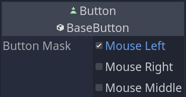

You can also enable middle and right clicks in the same way. As a checkbox controls them, you can also have any combination of enabled and disabled masks from listening to all events at once to none.